# Session 1

Ana Paula Sales

June 15, 2017

```r
library(data.table)
library(ggplot2)
library(mvtnorm)
source("~/Documents/projects/teaching/BayesComputation/code/priorEffect-functions.R")
source("~/Documents/projects/teaching/BayesComputation/code/AR1-functions.R")
```

## Outline

### Session 1: Bayesian computation basics

- Common distributions in R
- Choosing priors
- Effect of prior distribution on posterior
- Summarizing the posterior distribution analytically vs via simulation
- Bayesian hypothesis testing vs frequentist hypothesis testing

### Session 2: Introduction to stochastic simulation via AR(1) models and compositional sampling

- AR(1) model properties
- Sampling from AR(1) via compositional form of the joint distribution
- Reference Bayesian analysis
  - Posterior simulation
  - Forecasting: predictive simulation
- Latent AR(1): a first HMM

### More to come:

- Accept-reject sampling
- Importance sampling
- Gibbs sampling
- Metropolis-Hastings

## Session 1

### Sampling from and evaluating common distributions

- runif
- set.seed
- Exponential distribution
  - rXXX(): generates samples from the distribution
  - dXXX(): probability density function
  - pXXX(): cumulative distribution function
  - qXXX(): quantiles

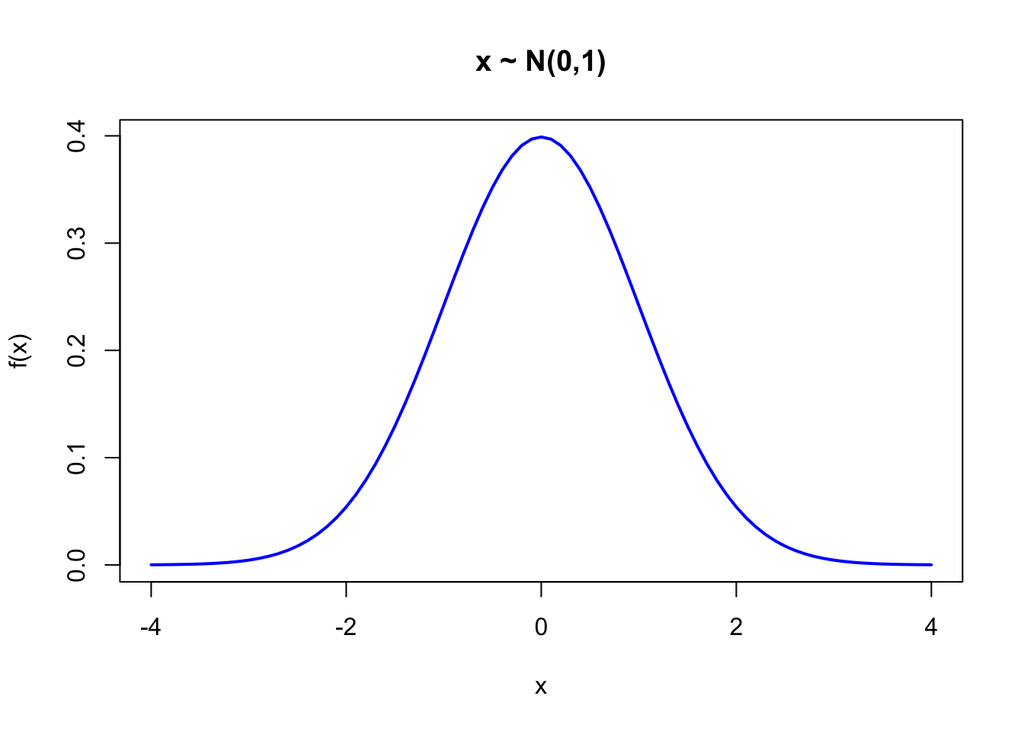

```r
x = seq(-4, 4, by = 0.1);
mu = 0
sd = 1


distnExpr = function(pars, distSymbol){
   a=paste0("x ~ ", distSymbol, "(", paste(pars,collapse=","), ")")
  return(a)
}

#normal density
y = dnorm(x, mu, sd);
plot(x, y, type = 'l', col = 'blue', lwd = 2, ylab = "f(x)", main = distnExpr(c(mu,sd),"N"))
```

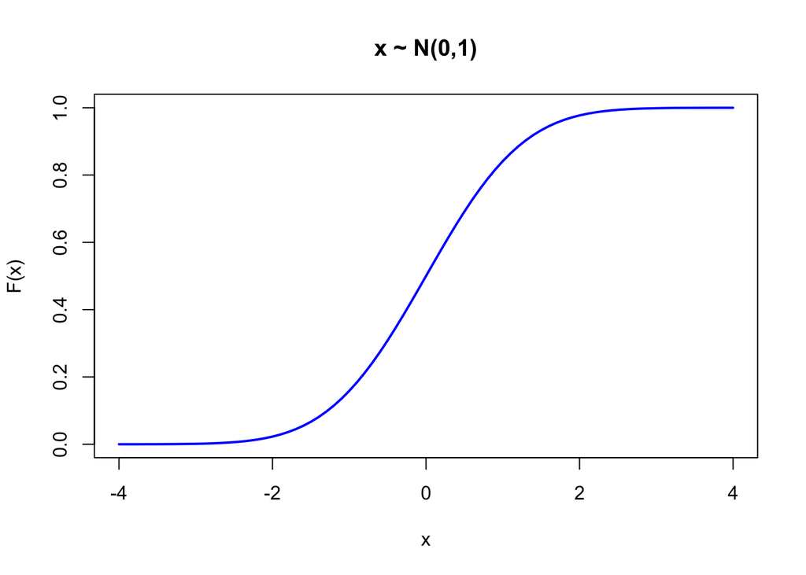

```r
#cumulative distribution
y = pnorm(x,mu,sd);
plot(x, y, type = 'l', col = 'blue', lwd = 2, ylab = "F(x)",main = distnExpr(c(mu,sd),"N"))
```

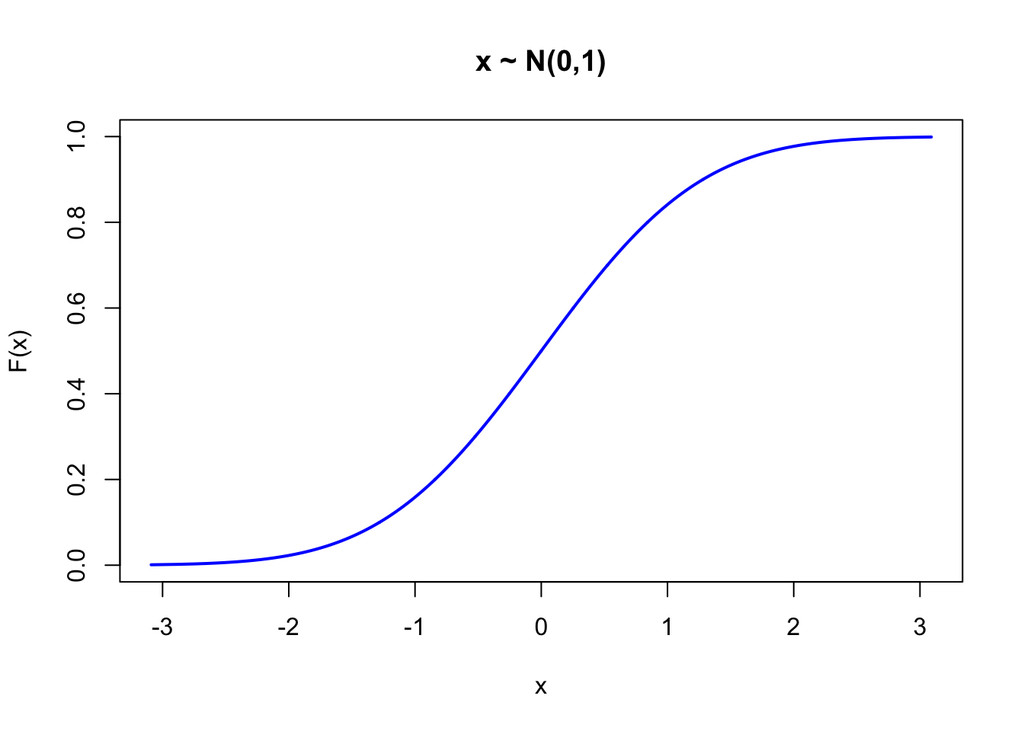

```r
#quantiles
p = seq(0.001, 0.999, by =0.001)
x = qnorm(p)
plot( x,p,type = 'l', lwd = 2, col = 'blue', ylab = "F(x)", main = distnExpr(c(mu,sd),"N"))
```

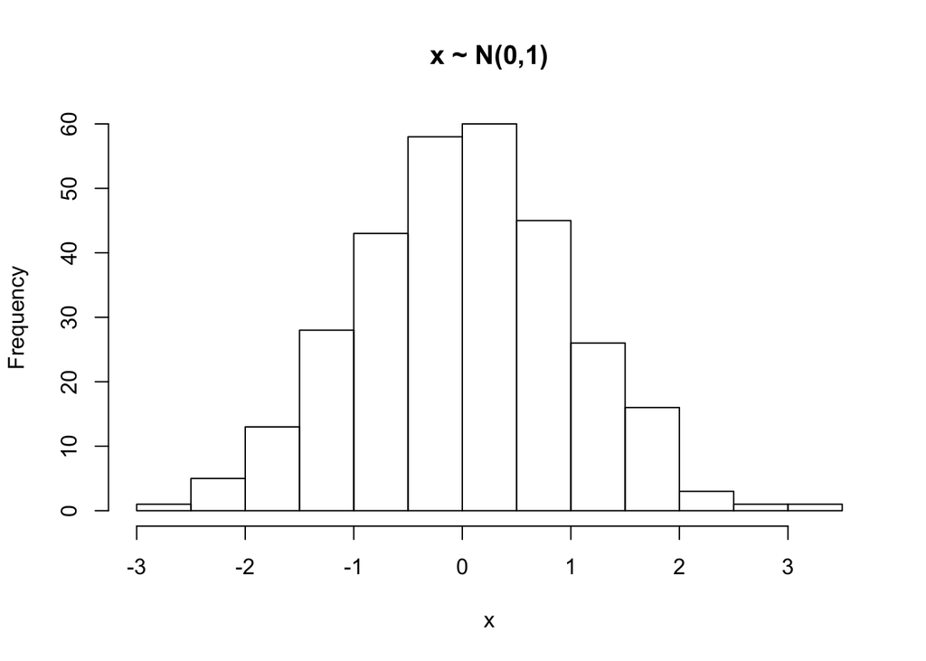

```r
#looking at samples with histograms
x = rnorm(300)
hist(x, main = distnExpr(c(mu,sd),"N"))
```

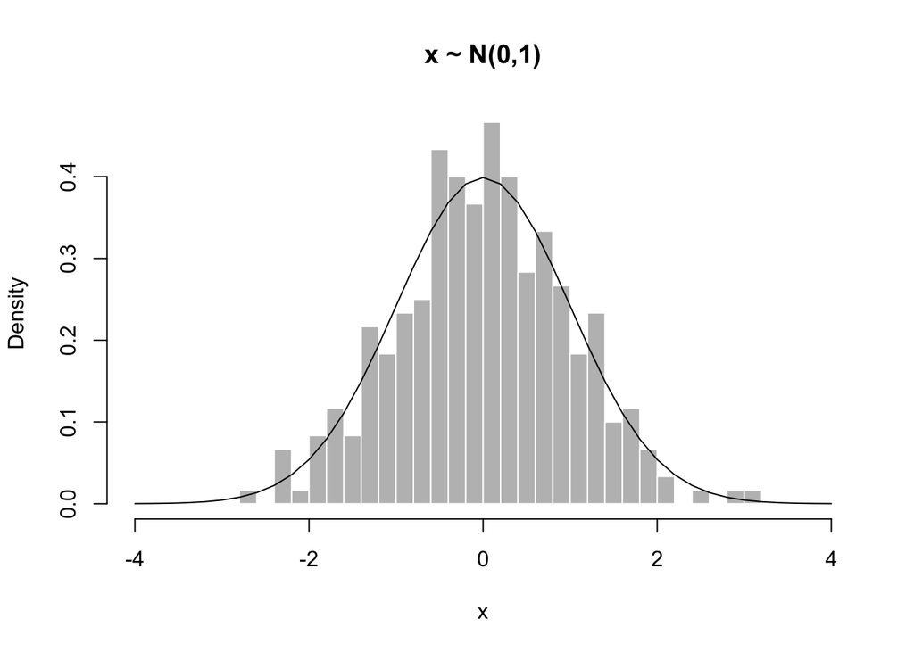

```r
#histogram bin size
b = seq(-4, 4, by = 0.2) # More narrow bins
hist(x, breaks = b, col = 'gray', border = 'white',freq=FALSE, main = distnExpr(c(mu,sd),"N"))

#adding theoretical density
lines(b, dnorm(b,mu,sd))
```

```r
#LAB
#explore dbeta and dbinom on your own
```

### Choosing a prior

Prior elicitation: Beta example

```r
# Say theta ~ .2
# P(theta > .8) is small .001 => P(theta < .8) ~ .999

#Mode of Be(a,b) = (a-1)/(a+b-2) = .2 => a = .25*b + .75
#Now we know theta ~ Be(b-3,b)
#P(theta > .8) ~ .001 => pbeta(.8, a,b) = 1 - .001.  Solve for b.

aGivenBAndM = function(b, m){
  return((m*(b-2) + 1)/(1-m))
}
findBetaB = function(b,
             m, # value of mode of beta
             q, # quantile
             p  # cummulative prob at quantile "q"
             ){
  res = pbeta(q,aGivenBAndM(b,m),b) - p
  return(res)
}

sol = uniroot(findBetaB, interval=c(1,100),m=.2, q=.8, p = 0.999)
sol
```

```
## $root
## [1] 5.416294
##
## $f.root
## [1] -1.352481e-08
##
## $iter
## [1] 12
##
## $init.it
## [1] NA
##
## $estim.prec
## [1] 6.103516e-05
```

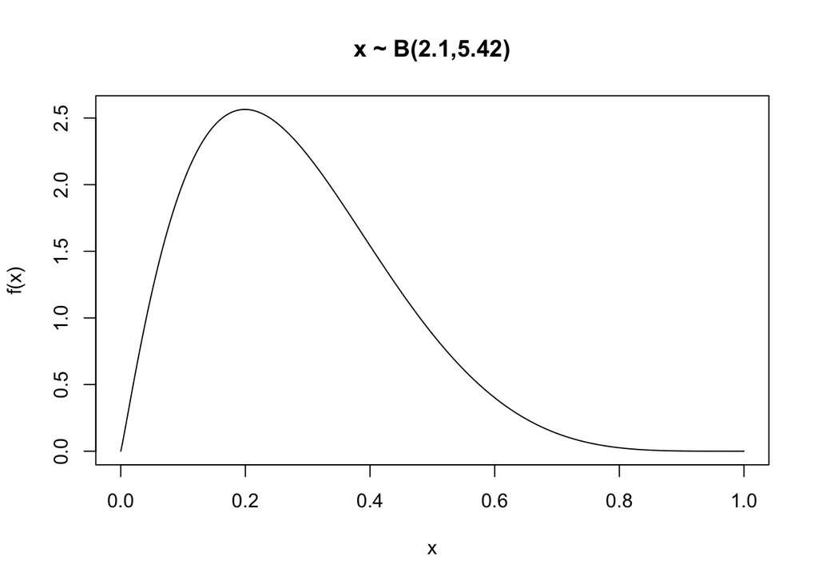

```r
b = round(sol$root,d=2)
a = round(aGivenBAndM(b,0.2),d=2)

x = seq(0,1,by=.001)
y =dbeta(x,a,b)
plot(x,y,type="l",ylab="f(x)", main = distnExpr(c(a,b),"B"))
```

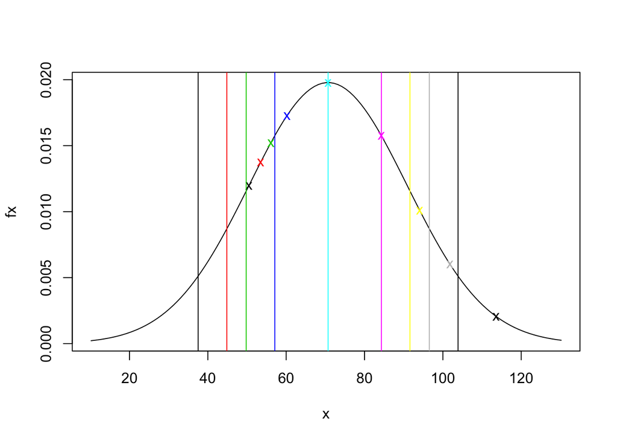

```r
w = c(50.5, 53.5, 56.1, 60.2, 70.7, 84.3, 94.1, 101.8, 113.6)
p = c(5,10,15,25,50, 75,85, 90,95)/100


#LAB EXERCISE:
#Prior elicitation for a Normally distributed variable: US female population weight



findNormPars = function(par,
             q50, # 50th percentile
             q75  # 75th percentile
             ){
  #res = pnorm(q1,par[1],par[2]) + pnorm(q2,par[1],par[2]) - p1 - p2
  mu = par[1]
  sigma = par[2]
  res = sum((pnorm(c(q50,q75),mu,sigma) - c(1/2,3/4))^2)
  return(res)
}
w.prior.sol = optim(c(50,10), findNormPars,q50= 70.7, q75 = 84.3)
mu = w.prior.sol$par[1]
sd = w.prior.sol$par[2]
x = seq(mu-3*sd,mu+3*sd,by=1)
fx = dnorm(x, mu, sd)
plot(x, fx, type="l")

#how good of a match is this anyways?
fw = dnorm(w,mu,sd)
points(w, fw,col=1:length(w),pch="x")
abline(v=qnorm(p,mu,sd),col=1:length(w))
```

### Effect of prior on posterior

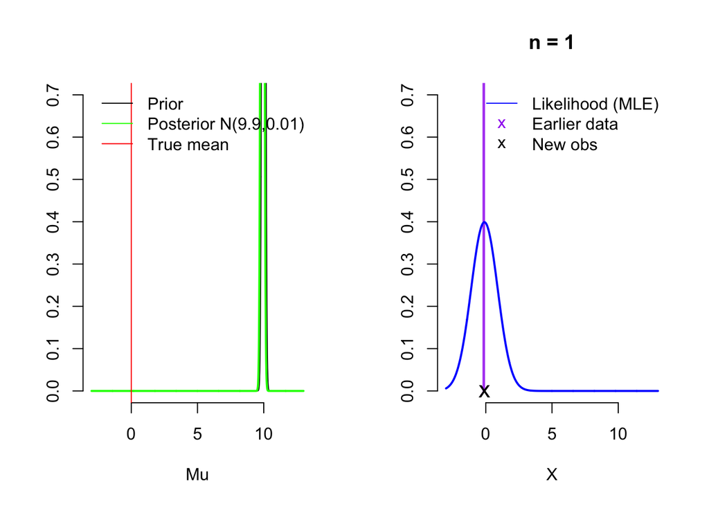

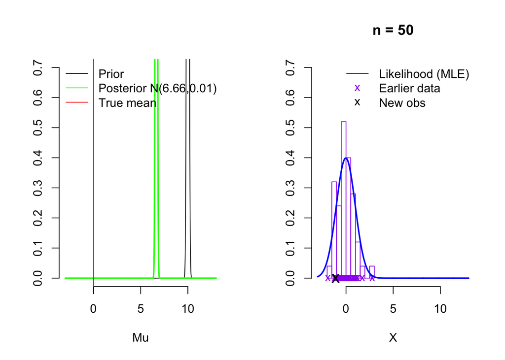

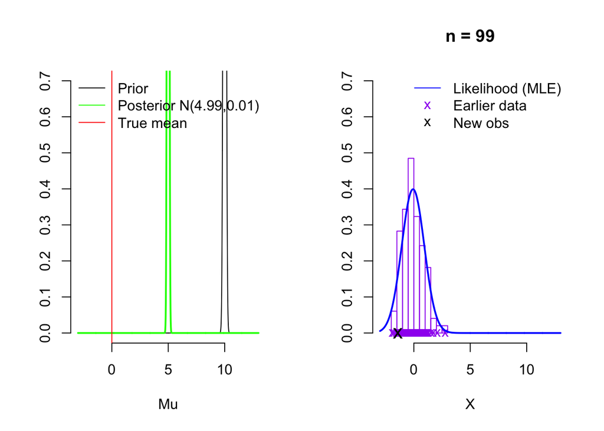

```r
known.sd=1
true.mean = 0

#prior same variance as data, but wrong mean (3)
prior.mean = 10
prior.sd = .10
sim.conjNormKnownVar(prior.mean = prior.mean,
                     prior.sd=prior.sd,
                     true.mean=true.mean,
                     known.sd=known.sd,
                     n.samples =100,
                     numIterationsToSkip = 49,
                     interactive=TRUE)
```

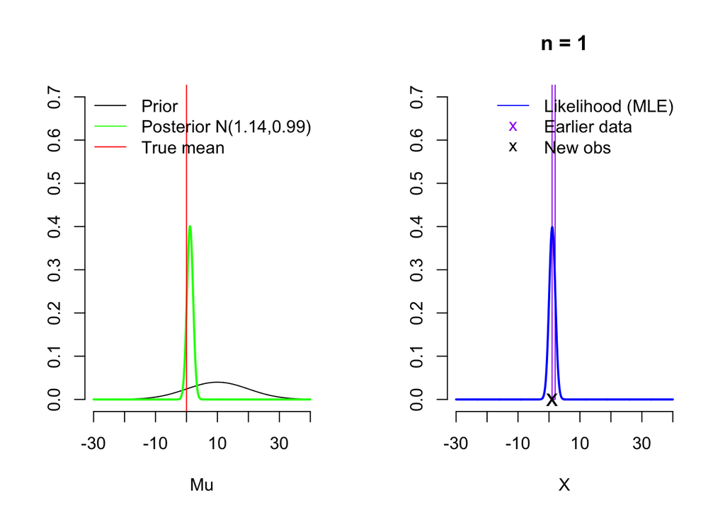

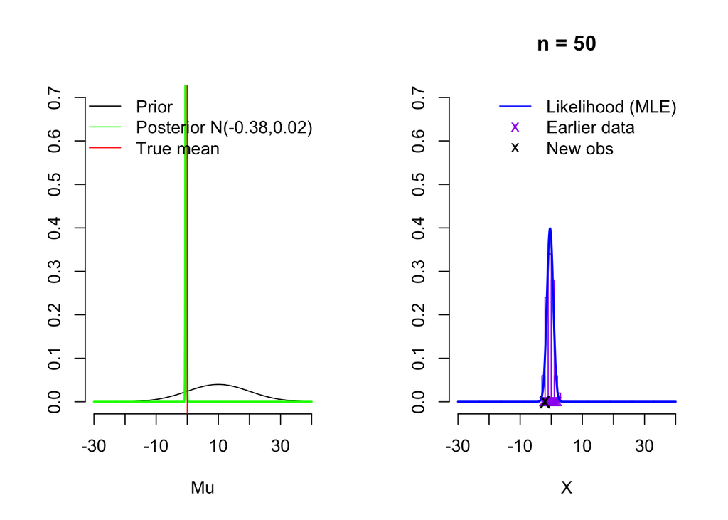

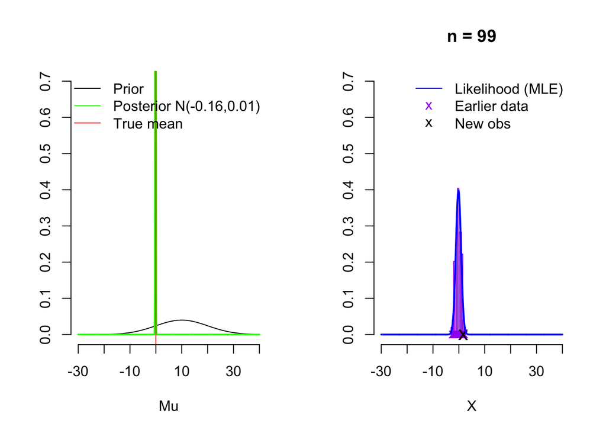

```r
#LAB EXERCISE:
#Explore more and less flat priors, more and less correct prior locations.  What are the implications on the posterior? What is a reasonable number of posterior samples?
#Explore beta-binomial posterior model


#prior very uncertain
prior.mean = 10
prior.sd = 10
sim.conjNormKnownVar(prior.mean = prior.mean,
                     prior.sd=prior.sd,
                     true.mean=true.mean,
                     known.sd=known.sd,
                     n.samples =100,
                     numIterationsToSkip = 49,
                     interactive=FALSE)
```

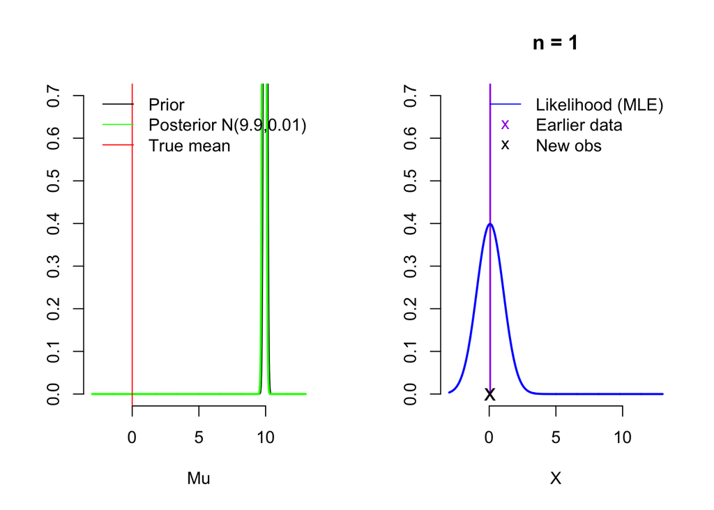

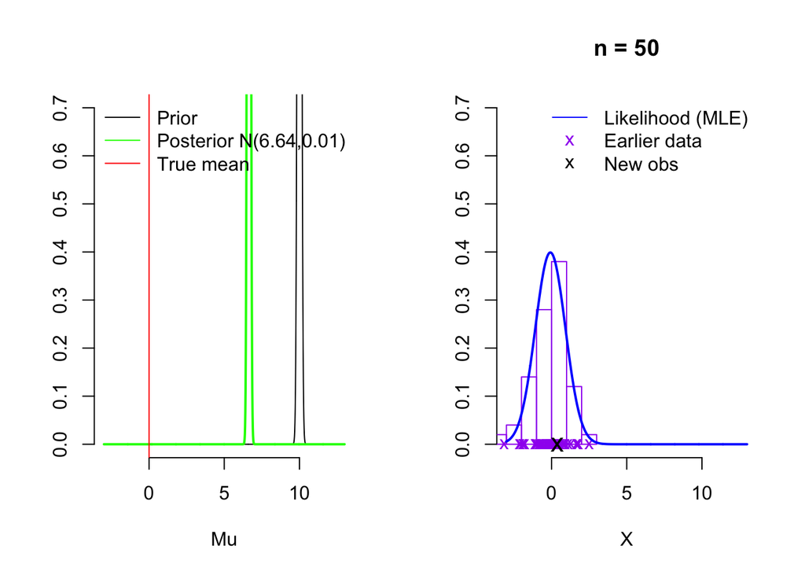

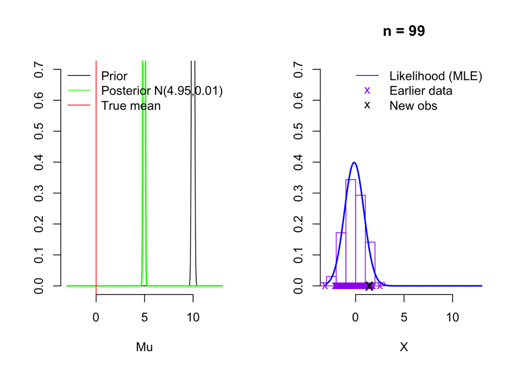

```r
#prior very certain, but wrong
prior.mean = 10
prior.sd = .10
sim.conjNormKnownVar(prior.mean = prior.mean,
                     prior.sd=prior.sd,
                     true.mean=true.mean,
                     known.sd=known.sd,
                     n.samples =100,
                     numIterationsToSkip = 49,
                     interactive=FALSE)
```

### Summarizing the posterior

Take a simple model like

x ~ N(mu, known.var)

mu ~ N(prior.mean,prior.var)

mu |x ~ N(post.mean,post.var)

```r
# x|mu ~ N(mu, know.var)
# mu ~ N(prior.mean, prior.var)
# mu |x ~ N(post.mean,post.var)

sum.x = 10
n.samples = 100

prior.mean = 0
prior.sd = 1
known.sd = 1

#POSTERIOR MEAN AND VARIANCE
##analytical
post.mean = ( prior.mean/prior.sd^2 + sum.x/known.sd^2) / (1/prior.sd^2 + n.samples/known.sd^2)
post.var = 1/(1/prior.sd^2 + n.samples/known.sd^2)
post.sd = sqrt(post.var)
paste(c("mean:", "var:"), sapply(c(post.mean, post.var), round, d=3))
```

```
## [1] "mean: 0.099" "var: 0.01"
```

```r
##simulation
post.samples = rnorm(n.samples, post.mean, post.sd)
paste(c("mean:", "var:"), sapply(c(mean(post.samples), var(post.samples)), round, d=3))
```

```
## [1] "mean: 0.088" "var: 0.008"
```

```r
#POSTERIOR PROB THAT MU LIES IN A GIVEN INTERVAL: P(a < mu < b | x)
a=0
b=1
##analytical
pnorm(b, post.mean, post.sd) - pnorm(a, post.mean, post.sd)
```

```
## [1] 0.8401409
```

```r
##simulation
mean(post.samples > a & post.samples < b)
```

```
## [1] 0.84
```

```r
#CENTRAL 95% CI
##analytical
c(qnorm(.025, post.mean, post.sd), qnorm(.975,post.mean, post.sd))
```

```
## [1] -0.0960138  0.2940336
```

```r
##simulation
quantile(post.samples, c(.025,.975))
```

```
##        2.5%       97.5%
## -0.05812923  0.28356012
```

### Bayesian hypothesis testing

```r
#Based on previously published data  "Anthropometric Reference Data for Children and Adults: United States, 2003–2006" (http://www.cdc.gov/nchs/data/nhsr/nhsr010.pdf), we think the over-20 US female population weight follows a Gaussian distribution with mean and standard deviation:
mu.w = w.prior.sol$par[1]
sd.w = w.prior.sol$par[2]
sapply(c(mu.w, sd.w), round, d=2)
```

```
## [1] 70.70 20.17
```

```r
#Suppose we go downtown SF and take the following sample:
xbar = 72
n = 55

#Now we want to test the hypothesis that the mean is indeed mu.w
#H0: mean = mu.w
#H1: mean != mu.w

#H0:  x|mu.w ~ N(mu.w, sd.w^2) =>
#     xbar|mu.w ~ N(mu.w, sd.w^2/n)
#p(xbar|mu.w) = dnorm(xbar, mean = mu.w, sd = sd.w/sqrt(n))
L0=dnorm(xbar, mean = mu.w, sd = sd.w/sqrt(n))

#H1:  x|mu.w ~ N(mu.w, xvar),
#     mu.w ~ N(mu0, var.mu) =>
#     xbar|mu.w ~ N(mu.w, var.xbar), var.xbar = var.mu + var.x/n
# Low information, flat-ish prior: var.mu = 2*var.w
var.w = sd.w^2
var.mu = var.w*2
var.xbar = var.mu + var.w/n
mu0 = mu.w
L1=dnorm(xbar, mu0, sqrt(var.xbar))

L0/L1
```

```
## [1] 9.405585
```

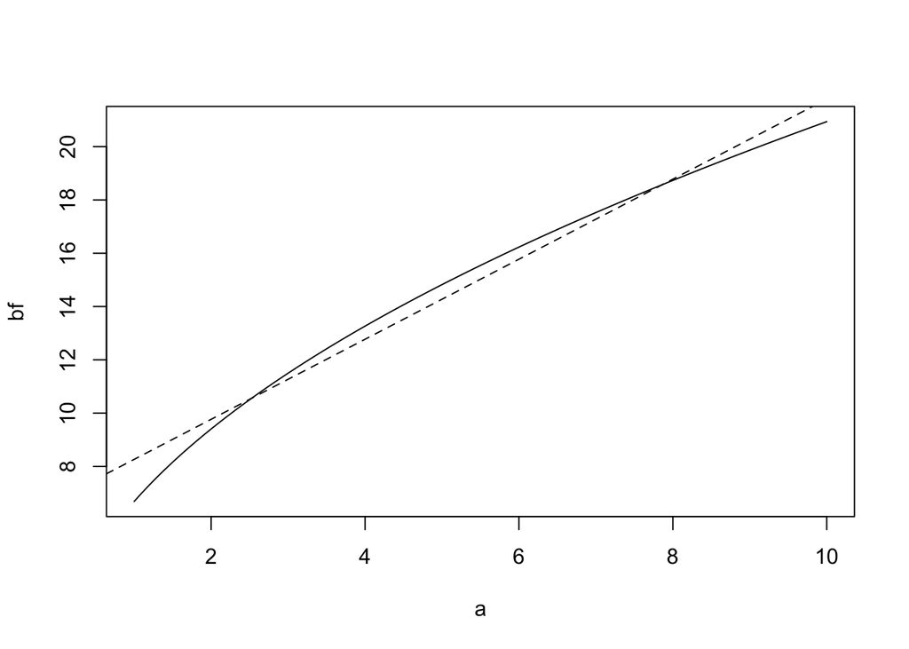

```r
BF = function(mu.w,
              sd.w,
              prior.var.multiplier,
              xbar,
              n){

  L0=dnorm(xbar, mean = mu.w, sd = sd.w/sqrt(n))

  var.w = sd.w^2
  var.mu = var.w*prior.var.multiplier
  var.xbar = var.mu + var.w/n
  L1=dnorm(xbar, mu.w, sqrt(var.xbar))

  return(L0/L1)
}

#LAB EXERCISE:
# Explore effect of prior flatness on BF
a=seq(1,10,by=.1)
bf =sapply(a, BF, mu.w=mu.w, sd.w = sd.w, xbar = xbar, n=n)
plot(bf~a,type="l")
abline(lm(bf~a)$coefficients,lty=2)
```

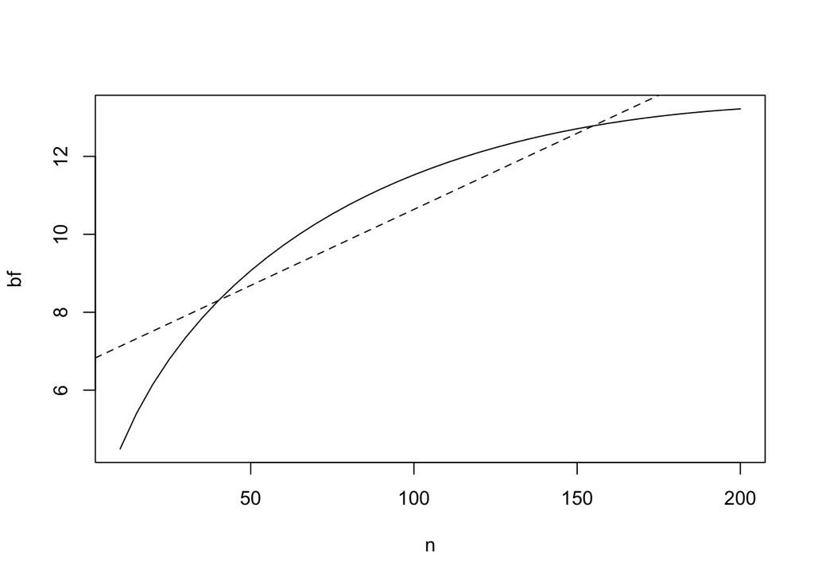

```r
#Explore effect of sample size on BF
n=seq(10,200,by=5)
bf =sapply(n, BF, mu.w=mu.w, sd.w = sd.w, xbar = xbar, prior.var.multiplier=2)
plot(bf~n,type="l")
abline(lm(bf~n)$coefficients,lty=2)
```

#### An important detour: p-values and frequentist hypothesis testing

What evidence against the null hypothesis does a p-value of 0.05 provide?  
In other words, p(H =0 | p-value = 0.05) = ? Address this question via simulation, as follows:

- H ~ Bern(pi)
- If H ==0, then sample y.bar ~ N(0, 1/n)
- Else if H ==1, then sample mu ~ N(0,1), and y.bar ~ N(mu, 1/n)
- Compute p-value, aka, 1 - 2*pnorm(z, mu, 1)
- Repeat the above steps many times
- Now compute p(H ==0| p-value )

```r
pval.simulation = function(n, pi, mu0, sigma2, num.trials){
  H = rbinom(num.trials, 1, pi)
  mu = rnorm(length(H), mean = mu0, sd = H*sigma2)
  pvalue = 2 *(1 - pnorm(abs(( rnorm(length(H), mean = mu, sd = 1/sqrt(n)) - mu)/(1/sqrt(n)))))
  prob.H0.given.pvalue =  sum(pvalue[H == 0] >= 0.049 & pvalue[H == 0] <= 0.05)/sum(pvalue >= 0.049 & pvalue <= 0.05)
  prob.H0.given.pvalue
  }

n = 30
pi = 0.5
num.trials = 100000
mu0 = 0


sigma2 = c(1,2,5,10,15,20,25,50,100)
pi = seq(0,1,by=.1)
probH0 = sapply(pi, function(x){sapply(sigma2, pval.simulation, n = n, mu0 = mu0, num.trials = num.trials, pi = x)})
probH0 = cbind(probH0, sigma2)

plot(NA, xlim = range(pi), ylim = range(probH0[,-ncol(probH0)]), xlab = expression(pi), ylab = expression(paste("P(", H[0], "|pval = 0.05)")))
apply(probH0, 1, function(y){lines(y = y[1:(length(y)-1)],x = pi,col=y[length(y)],type="b")})
```

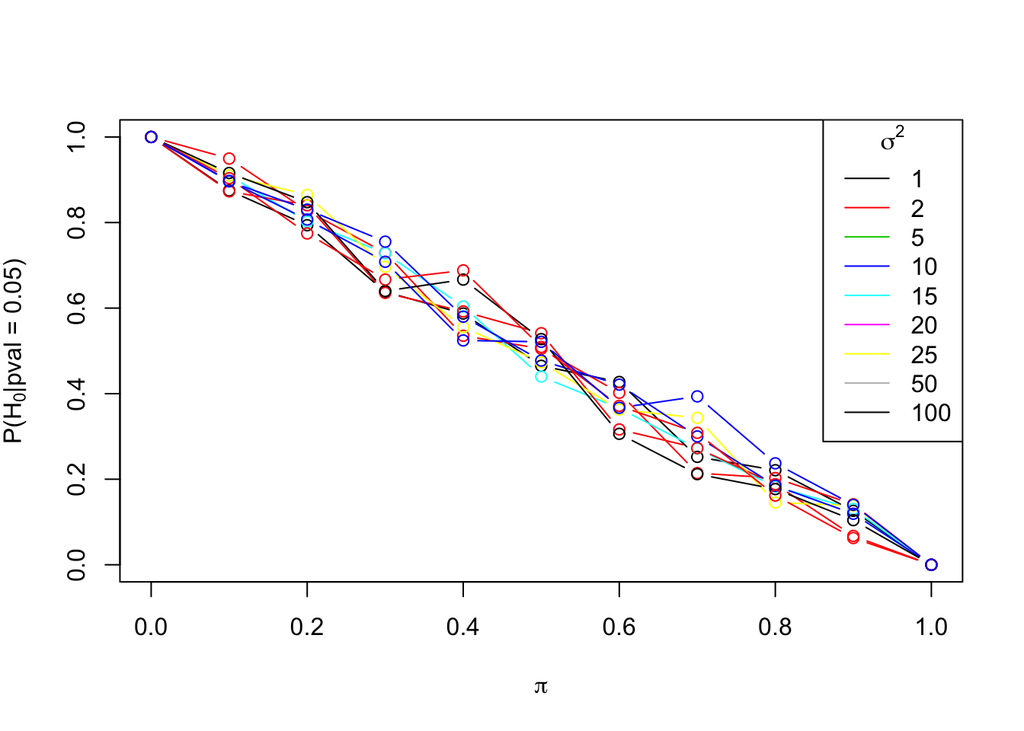

```r
legend("topright", legend=sigma2, col = 1:length(sigma2),lty=1,title = expression(sigma^2))
```

```r
##LAB EXERCISE:
# Explore effect relationship between p-value and p(H0|Data) for various values of pi, num.trials, n
```